# [MOD3] : Introduction à la régression multiple

# 2. EXPLORATION DE LA RELATION

La manière la plus simple d’analyser la relation entre Y et plusieurs X1:n est d’utiliser un simple plot

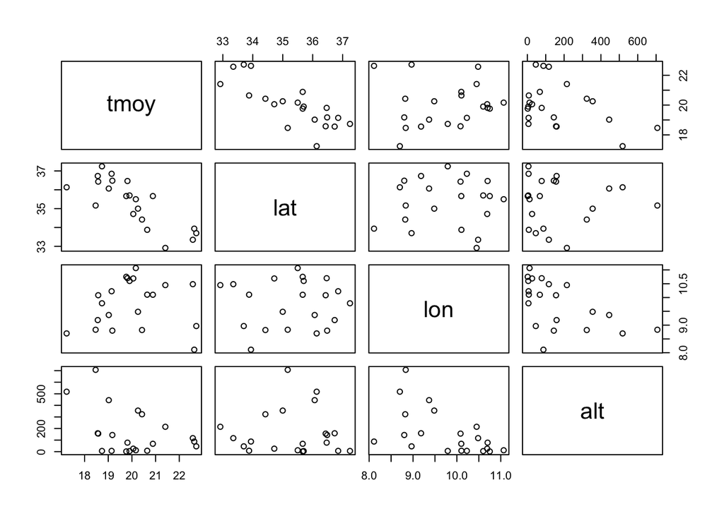

```r
plot(don_reg)
```

Il est possible aussi d’afficher la matrice des coefficients de corrélation entre ces 4 variables (cf. cours précédent) :

```r
cor(don_reg)
```

```
            tmoy         lat         lon         alt
tmoy  1.00000000 -0.79665265  0.06494534 -0.40454447
lat  -0.79665265  1.00000000  0.02982053 -0.01528285
lon   0.06494534  0.02982053  1.00000000 -0.54596270
alt  -0.40454447 -0.01528285 -0.54596270  1.00000000
```

Ou encore d’utiliser la fonction le package `corrplot()` et sa fonction, pour faciliter la lecture des relations

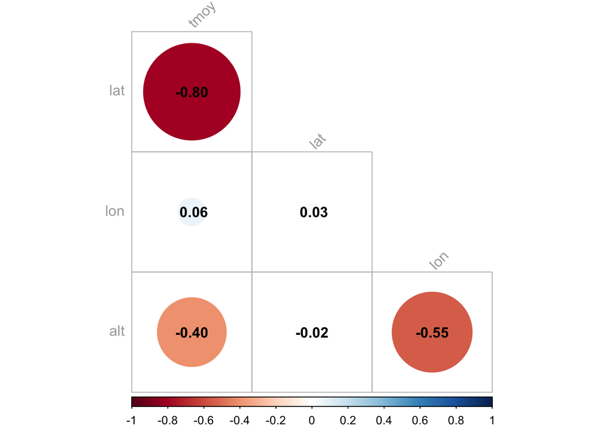

```r
library(corrplot)
# Ce graphique utilise les données de la matrice de corrélation : cor(don_reg)
corrplot(cor(don_reg), type = "lower",
         diag=FALSE, tl.col = "dark grey", tl.srt = 45,addCoef.col = TRUE)
```

#### > Existe-t-il des **relations significatives** ? quelle est la variable la plus fortement corrélée avec *tmoy* ?

# 3. VERS LA REGRESSION MULTIPLE PAR LA METHODE “STAGEWISE” ou comment construire un modèle petit à petit

Nous allons construire un modèle permettant d’expliquer les variations des températures moyennes en Tunisie (Y) à partir de plusieurs facteurs explicatifs (X1:n). La régression multiple “stagewise” nous permettra de revoir les étapes de la régression simple et de construire un modèle multiple. Voici les étapes :

## modele1

::: ATTENTION, texte à trou, à vous de le remplir  
Rappel : on écrit la variable à expliquer [Y] en fonction [~] de la variable explicative [X], soit lm(Y~X). Choisir ici les variables en question.

```r
modele1 <- lm(...)
summary(modele1)
```

Est-ce que la relation est significative ? Quel est son sens ? Quelle est son intensité ?  
Que doit-on vérifier au-delà de la *p-value* et de la significativité pour valider le modèle ?  
Quel est le pouvoir explicatif de cette relation ?

Notez que le R ajusté est utile lorsque l’on compare plusieurs modèles sur un même jeu de données.

## modele2

```r
corrplot(cor(don_reg[,c("...", "...")],
             m1$residuals),
         addCoef.col = TRUE)
modele2 <- lm(m1$residuals ~ don_reg$...)
summary(modele2)
```

Si la nouvelle variable est significative avec ce qui n’a pas été expliqué par le premier modèle (= les résidus), alors on continue.

## modele3

Il ne reste plus qu’une variable à tester sur les résidus.

```r
modele3 <- lm(m2$residuals ~ don_reg$...)
summary(m3)
```

Chacune des variables retenues, *in fine*, explique significativement une partie non expliquée auparavant. Il s’agit à présent de combiner l’ensemble des variables dans un seul **modèle de régression multiple**.

# 4. REGRESSION MULTIPLE LINEAIRE

Rappel : Pour construire un modèle linéaire simple `lm(Y~X)`.  
Pour construire un modèle linéaire multiple : `lm(Y\~X1+X2+X3...)`

Construire alors le modèle multiple à partir des variables sélections précédemment.

```r
modele_final <- lm(tmoy ~ ... + ..., data=don_reg)
summary(modele_final)
plot(modele_final)
```

#### > Quelles sont vos conclusions ?

#### > Quelle est l’**équation du modèle** ?

# 5. COLINEARITÉ ENTRE VARIABLES ou comment, plus largement, sélectionner les variables explicatives ?

Même si ce module n’est qu’une introduction à la régression multiple linéaire, nous aimerions aborder la notion de la multicolinéarité ou la colinéarité entre les variables explicatives (c’est lorsqu’il existe une forte relation linéaire entre 2 ou + variables explicatives). Cette colinéarité est parfois préjudiciable, elle entraîne une instabilité dans l’estimation des coefficients et cela peut aller jusqu’à fausser les tests statistiques. Une partie de l’explication apportée par une variable peut être déjà prise en compte dans une autre. L’idéal serait que les variables soient indépendantes (cf. à ce propos l’[article](https://freakonometrics.hypotheses.org/61090) du blog de Freakonometrics d’Arthur Charpentier).

L’objectif principal d’une modélisation à partir de variables est de rechercher un équilibre entre le modèle le plus simple et le meilleur ajustement.  
Plusieurs méthodes cherchent à sélectionner au mieux les variables :

- approche exhaustive : toutes les combinaisons possibles sont testées et on choisit la “meilleure” ; rapidement très lourde à mettre en place ;
- approche *backward* : on met l’ensemble des variables et petit à petit on enlève celle(s) avec la plus grande valeur de *p-value* jusqu’à n’avoir que des fortement significatives ;
- approche *forward* : c’est l’inverse, on ajoute petit à petit les variables les plus significatives ;
- approche *stepwise* : un mélange des 2 précédentes ;
- et l’approche *stagewise* que nous avons vue dans la section précédente.

## 6. COMPARAISON DE MODÈLES

Plusieurs critères permettent de comparer plusieurs modèles, les plus connus étant AIC (*An Information Criterion* d’Akaike) et le BIC (Bayesian Information Criterion), basés sur des compromis : plus les valeurs sont petites, plus le modèle est adapté. Sous `R`:

```r
AIC(modele)
BIC(modele)
```

Si vous hésitez entre 2 modèles (2 combinaisons de variables), vous pouvez tester par une *analyse de la variance* les 2 modèles. En d’autres termes, vous cherchez à savoir l’influence d’une ou de plusieurs variables dans un modèle, tout en prenant en considération les autres.

```r
anova(mod1,mod2)
```

Si la significativité est supérieure à 0,05 (ou 0,10), alors vous pouvez conclure que les variables introduites ne contribuent pas significativement.